# hw4

Author

Aryan Singh

https://github.com/aryansinghmich/stats_506

```r
# environment set up
setwd("/Users/aryansingh/Desktop/stats_506_git/hw3")
pacman::p_load(tidyverse, nzelect, knitr, infer)
```

# Problem 1

## Part A

```r
nzge %>% group_by(election_year, voting_type) %>%
  summarise(total_votes = sum(votes, na.rm = T), .groups = "drop") %>%
  arrange(desc(total_votes)) %>%
  rename(`Election Year` = election_year, `Voting Type` = voting_type, `Total Votes` = total_votes) %>% kable()
```

| Election Year | Voting Type | Total Votes |
| --- | --- | --- |
| 2014 | Party | 2416479 |
| 2014 | Candidate | 2375493 |
| 2008 | Party | 2356536 |
| 2008 | Candidate | 2325598 |
| 2005 | Party | 2286190 |
| 2005 | Candidate | 2260670 |
| 2011 | Party | 2257336 |
| 2011 | Candidate | 2225766 |
| 2002 | Party | 2040248 |
| 2002 | Candidate | 2022115 |

## Part B

```r
nzge %>% filter(election_year == 2014, voting_type == "Candidate") %>% group_by(party) %>%
  summarise(total_votes = sum(votes, na.rm = T), .groups = "drop") %>%
  mutate(percent_of_vote = 100 * total_votes / sum(total_votes)) %>%
  arrange(desc(percent_of_vote)) %>%
  rename(`Party` = party, `Total Votes` = total_votes, `Percent of Vote` = percent_of_vote) %>% kable()
```

| Party | Total Votes | Percent of Vote |
| --- | --- | --- |
| National Party | 1081787 | 45.5394733 |
| Labour Party | 801287 | 33.7313981 |
| Green Party | 165718 | 6.9761519 |
| Conservative Party | 81075 | 3.4129757 |
| New Zealand First Party | 73384 | 3.0892114 |
| Maori Party | 42108 | 1.7726005 |
| MANA Movement | 32333 | 1.3611069 |
| Informal Candidate Votes | 27886 | 1.1739037 |
| ACT New Zealand | 27778 | 1.1693573 |
| United Future | 14722 | 0.6197450 |
| Aotearoa Legalise Cannabis Party | 4936 | 0.2077884 |
| Internet Party | 4848 | 0.2040840 |
| Democrats for Social Credit | 4647 | 0.1956226 |
| Ban1080 | 4448 | 0.1872453 |
| Independent | 3864 | 0.1626610 |
| NZ Independent Coalition | 1929 | 0.0812042 |
| Focus New Zealand | 1797 | 0.0756475 |
| Money Free Party | 391 | 0.0164597 |
| Communist League | 135 | 0.0056830 |
| Climate Party | 116 | 0.0048832 |
| Human Rights Party | 76 | 0.0031993 |
| The Expats | 70 | 0.0029468 |
| Alliance | 59 | 0.0024837 |
| NZ Economic Euthenics Party | 51 | 0.0021469 |
| Patriotic Revolutionary Front | 48 | 0.0020206 |

## Part C

```r
nzge %>% group_by(election_year, voting_type, party) %>%
  summarise(total_votes = sum(votes, na.rm = T), .groups = "drop") %>%
  group_by(election_year, voting_type) %>%
  slice_max(order_by = total_votes, n = 1, with_ties = F) %>% ungroup() %>%
  pivot_wider(names_from = voting_type,
              values_from = c(party, total_votes),
              names_sep = "_") %>%
  arrange(election_year) %>%
  rename(`Election Year` = election_year, `Winning Candidate` = party_Candidate, `Winning Party` = party_Party, `Candidate Votes` = total_votes_Candidate, `Party Votes` = total_votes_Party) %>% kable()
```

| Election Year | Winning Candidate | Winning Party | Candidate Votes | Party Votes |
| --- | --- | --- | --- | --- |
| 2002 | Labour Party | Labour Party | 891866 | 838219 |
| 2005 | National Party | Labour Party | 902874 | 935319 |
| 2008 | National Party | National Party | 1072024 | 1053398 |
| 2011 | National Party | National Party | 1027696 | 1058636 |
| 2014 | National Party | National Party | 1081787 | 1131501 |

# Problem 2

```r
atp_2019 <- read_csv("https://raw.githubusercontent.com/JeffSackmann/tennis_atp/refs/heads/master/atp_matches_2019.csv")
```

## Part A

```r
atp_2019 %>% distinct(tourney_id, tourney_name, tourney_level) %>%
  arrange(tourney_level, tourney_name) %>%
  summarise(num_tournaments = n()) %>% kable()
```

| num_tournaments |
| --- |
| 128 |

There were 128 ATP tournaments in 2019 in this dataset.

## Part B

```r
multi_winners <- atp_2019 %>% filter(round == "F") %>%
  group_by(winner_name) %>%
  summarise(num_tournaments_won = n_distinct(tourney_id), .groups = "drop") %>%
  filter(num_tournaments_won > 1) %>%
  arrange(desc(num_tournaments_won))
multi_winners %>% kable()
```

| winner_name | num_tournaments_won |
| --- | --- |
| Dominic Thiem | 5 |
| Novak Djokovic | 5 |
| Daniil Medvedev | 4 |
| Rafael Nadal | 4 |
| Roger Federer | 4 |
| Alex De Minaur | 3 |
| Stefanos Tsitsipas | 3 |
| Benoit Paire | 2 |
| Cristian Garin | 2 |
| Jo-Wilfried Tsonga | 2 |
| Matteo Berrettini | 2 |
| Nick Kyrgios | 2 |

```r
multi_winners %>% summarise(num_players_more_than_one = n(), max_tournaments_won = max(num_tournaments_won)) %>% kable()
```

| num_players_more_than_one | max_tournaments_won |
| --- | --- |
| 12 | 5 |

In the 2019 ATP season, 12 players won more than one tournament. The players with the highest number of tournament victories were Dominic Thiem and Novak Djokovic, with each winning 5 tournaments.

## Part C

```r
aces_long <- atp_2019 %>% select(w_ace, l_ace) %>%
  pivot_longer(cols = c(w_ace, l_ace),
               names_to = "player_type",
               values_to = "aces") %>%
  mutate(player_type = if_else(player_type == "w_ace", "Winner", "Loser")) %>%
  drop_na(aces)


aces_long %>% group_by(player_type) %>%
  summarise(mean_aces = mean(aces, na.rm = T),
            sd_aces = sd(aces, na.rm = T),
            n = n()) %>% kable()
```

| player_type | mean_aces | sd_aces | n |
| --- | --- | --- | --- |
| Loser | 5.792502 | 5.631426 | 2694 |
| Winner | 7.497402 | 6.065966 | 2694 |

```r
obs_diff <- aces_long %>%
  specify(aces ~ player_type) %>%
  calculate(stat = "diff in means", order = c("Winner", "Loser")) %>%
  pull(stat)

null_dist <- aces_long %>%
  specify(aces ~ player_type) %>%
  hypothesize(null = "independence") %>%
  generate(reps = 5000, type = "permute") %>%
  calculate(stat = "diff in means", order = c("Winner", "Loser"))

p_val <- null_dist %>% get_p_value(obs_stat = obs_diff, direction = "greater")
tibble(observed_diff = obs_diff, p_value = p_val$p_value) %>% kable()
```

| observed_diff | p_value |
| --- | --- |
| 1.7049 | 0 |

The average number of aces for winners (~ 7.50) is statistically higher than for losers (~ 5.79), yielding an observed mean difference of 1.70 aces per match (permutation test produced a p-value ~ 0)

## Part D

```r
atp_2019 %>%
  pivot_longer(cols = c(winner_name, loser_name), names_to = "match_result", values_to = "player_name") %>%
  mutate(is_win = if_else(match_result == "winner_name", 1, 0)) %>%
  group_by(player_name) %>%
  summarise(matches = n(), wins = sum(is_win, na.rm = T), win_rate = wins / matches, .groups = "drop") %>%
  filter(matches >= 5) %>% filter(win_rate == max(win_rate)) %>% arrange(desc(win_rate)) %>% kable()
```

| player_name | matches | wins | win_rate |
| --- | --- | --- | --- |
| Rafael Nadal | 69 | 60 | 0.8695652 |

Rafael Nadal had the highest win rate among players with at least five matches in 2019. He played 69 matches and won 60, giving him a win rate of approximately ~0.87 (86.96%).

# Problem 3

```r
covid <- read_csv("https://raw.githubusercontent.com/nytimes/covid-19-data/refs/heads/master/rolling-averages/us-states.csv")
```

## Part A

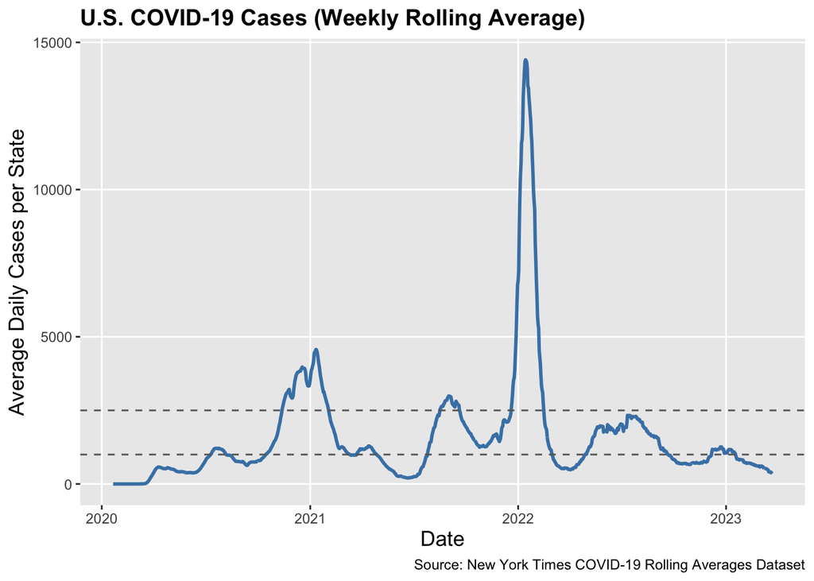

```r
covid %>% group_by(date) %>%
  summarise(avg_cases = mean(cases_avg, na.rm = T)) %>%
  ggplot(aes(x = date, y = avg_cases)) +
  geom_line(color = "steelblue", linewidth = 1) +
  geom_hline(yintercept = 2500, linetype = "dashed", color = "gray40") +
  geom_hline(yintercept = 1000, linetype = "dashed", color = "gray40") +
  labs(title = "U.S. COVID-19 Cases (Weekly Rolling Average)",
    x = "Date",
    y = "Average Daily Cases per State",
    caption = "Source: New York Times COVID-19 Rolling Averages Dataset"
  ) + theme(plot.title = element_text(face = "bold", size = 14),
    plot.subtitle = element_text(size = 12),
    axis.title = element_text(size = 13),
    panel.grid.minor = element_blank()
  )
```

There were approximately 3 major (over 2500 average daily cases per state) and 4 minor (over 1000 average daily cases per state) spikes in COVID-19 cases between 2020 and 2023. The Omicron wave in early 2022 stands out as the largest peak.

## Part B

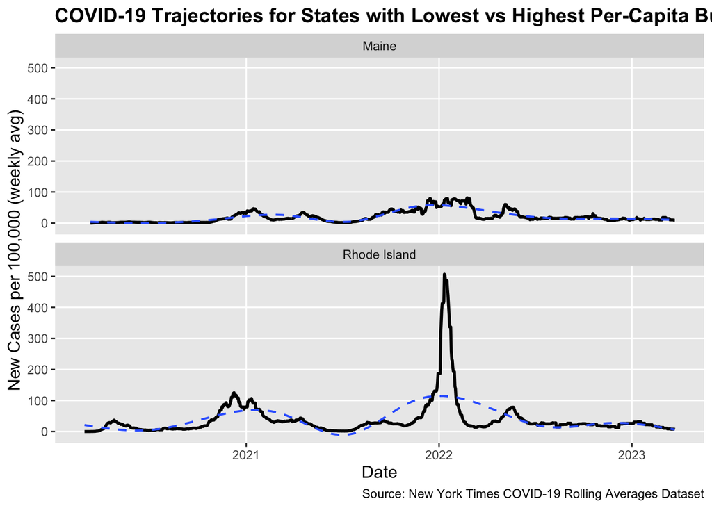

```r
covid %>% group_by(state) %>%
  mutate(total_per_100k = sum(cases_avg_per_100k, na.rm = T)) %>%
  ungroup() %>%
  filter(total_per_100k %in% range(total_per_100k)) %>%
  ggplot(aes(x = date, y = cases_avg_per_100k)) +
  geom_line(linewidth = 1) +
  geom_smooth(se = FALSE, linewidth = 0.7, linetype = "dashed") +
  facet_wrap(~ state, ncol = 1, scales = "fixed") +
  labs(title = "COVID-19 Trajectories for States with Lowest vs Highest Per-Capita Burden",
    x = "Date",
    y = "New Cases per 100,000 (weekly avg)",
    caption = "Source: New York Times COVID-19 Rolling Averages Dataset"
  ) + theme(plot.title = element_text(face = "bold", size = 14),
    plot.subtitle = element_text(size = 12),
    axis.title = element_text(size = 12),
    legend.position = "none",
    panel.grid.minor = element_blank()
  )
```

Rhode Island (highest per-capita burden) shows frequent, sharp, and high-amplitude spikes, including a major surge during the Omicron wave in early 2022 that reached over 500 new cases per 100,000. Maine (lowest per-capita burden) has a flatter, steadier trajectory with smaller peaks and lower overall case rates throughout the pandemic.

## Part C

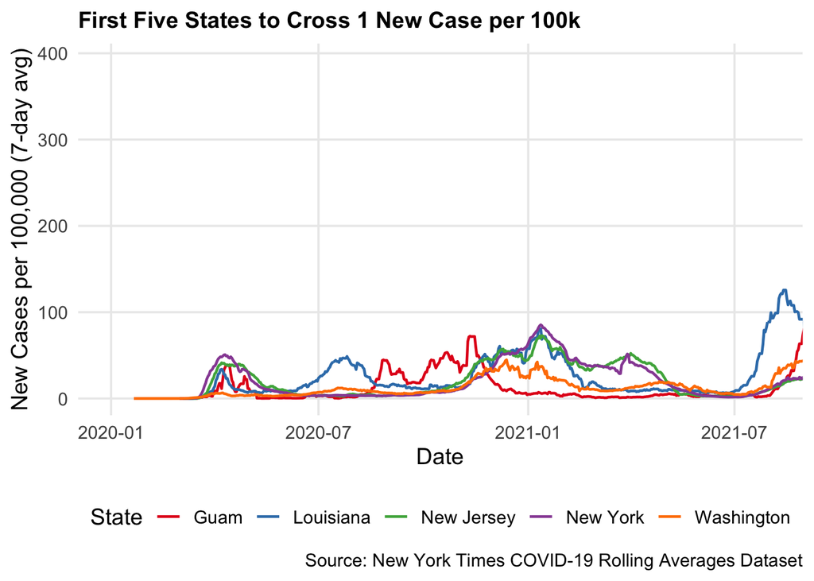

```r
# first 5 states to cross 1 case per 100k
first_five <- covid %>% group_by(state) %>%
  summarise(first_significant_date = min(date[cases_avg_per_100k > 1], na.rm = T)) %>%
  arrange(first_significant_date) %>%
  slice_head(n = 5) %>% pull(state)

covid %>%
  filter(state %in% first_five) %>%
  ggplot(aes(x = date, y = cases_avg_per_100k, color = state)) +
  geom_line(linewidth = 0.8) +
  scale_color_brewer(palette = "Set1") +
  coord_cartesian(xlim = as.Date(c("2020-01-01", "2021-08-01"))) +
  labs(title = "First Five States to Cross 1 New Case per 100k",
    x = "Date",
    y = "New Cases per 100,000 (7-day avg)",
    color = "State",
    caption = "Source: New York Times COVID-19 Rolling Averages Dataset"
  ) + theme_minimal(base_size = 14) +
  theme(plot.title = element_text(face = "bold", size = 14),
    plot.subtitle = element_text(size = 12),
    legend.position = "bottom",
    panel.grid.minor = element_blank()
  )
```